# RadNet Exploratory Data Analysis with RStudio

Wendy Bisset

April 2, 2018

=============================================================

## Data Source and Background Information

The US Environmental Protection Agency maintains several public databases on environmental data.[^1] One such database, **RadNet**,[^2] is a system of geographically distributed stations which sample and test for a number of radiochemical analytes (e.g., gross beta (β), cesium-137, iodine-131) in the nation’s air, precipitation, and drinking water. RadNet provides historical data to estimate long-term trends in environmental radiation levels and as a means to estimate levels of radioactivity in the environment. The stations are located across the US as well as American Territories. The current RadNet database primarily consists of data collected since 1978 though some data dates back to 1973 from RadNet’s precursor, ERAMS (Environmental Radiation Ambient Monitoring System).

All data was downloaded as .csv files from the RadNet website. According to the EPA’s [Envirofacts Data Service API](https://www.epa.gov/enviro/web-services) data output is limited to 10000 rows of data at a time from a maximum of three tables. Consequently, the data for each media type was downloaded by decade (up-to 1989, 1990-1999, 2000-2009, 2010-2017) and the resulting .csv files were loaded into RStudio and then merged[^3] into a single R dataframe.

Variables also include units of measure, e.g. size of sample (g, L) or time of decay (sec, min, hour, day, year). No filters or limitations were placed on location or types of radionuclides analysed. Other variables such as project numbers, surface water locations, sample collection start etc., exist in the RadNet database, but in effort to to control file size and project scope, these data were not downloaded.

## Data Overview -

The original raw consolidated dataframe has 19 variables and 504092 observations. One variable was added as a tracker in the merge operation to determine from which media dataframe the observation originated. The top variables of interest from a casual glance are the locations of the monitoring stations, the types of samples collected and the variety of analytes listed. Dates and analysis amounts will be helpful in the investigation of these variables. Several variables are added to provide methods for displaying locations or for easy summarization of other variables and categories.

Variable names were shortened and several variables were recast as factors with ordered levels where it made sense that an inmposed order may be useful, e.g., S(econd) < M(inute) < H(our) < D(ay) < Y(ear). In the event of possible date manipulations, the date field was changed to type DATE instead of CHR.[^4]

```
[1] 504092     20
      id            V_ERAMS_MATRIX_SAMPLE_ANALYSIS.MAT_ID
 Length:504092      Length:504092
 Class :character   Class :character
 Mode  :character   Mode  :character




 V_ERAMS_MATRIX_SAMPLE_ANALYSIS.SAMP_ID
 Length:504092
 Class :character
 Mode  :character




 V_ERAMS_MATRIX_SAMPLE_ANALYSIS.ANA_SIZE
 Min.   :     0
 1st Qu.:     2
 Median :   500
 Mean   :  6123
 3rd Qu.:  4872
 Max.   :532000
 NA's   :3195
 V_ERAMS_MATRIX_SAMPLE_ANALYSIS.ANA_UNIT
 Length:504092
 Class :character
 Mode  :character




 V_ERAMS_MATRIX_SAMPLE_ANALYSIS.ANA_PROC_NUM
 Min.   :  1.00
 1st Qu.:  1.00
 Median :  9.00
 Mean   : 22.22
 3rd Qu.:  9.00
 Max.   :170.00
```

[output cut: 54 more lines]

```
 3rd Qu.:1.60e+03
 Max.   :1.05e+11
 NA's   :251749
 V_ERAMS_RESULTS_ANALYTE.HALF_LIFE_TIME_UNIT
 Length:504092
 Class :character
 Mode  :character




 V_ERAMS_RESULTS_ANALYTE.ANALYTE_NAME
 Length:504092
 Class :character
 Mode  :character
```

## Univariate Analysis Plots and Variable Audit

A simple analyses of each variable (count, table, summary, or distribution) greatly helped to understand a bit more about the data. The first variables of interest were those dealing with location, the city and state information provides the potential of visualizing data spatially.

It was discovered that the package `ggmap`[^5] would make it possible to represent location information geographically.[^6]<sup>,</sup>[^ggmap_vis2] Using the provided city and state information, the latitude and longitude of each location was added using the function `geocode()` .[^7]<sup>,</sup>[^8] The packages `choroplethr` and `choroplethrMaps` also allow for geographical representation of various values on a shaded and keyed `Choropleth Map`.[^9]<sup>,</sup>[^10]

There are 324 unique sampling locations with a numerical LOC_NUM tied to one of 280 cities in the US, US territories, the Pananma Canal (PC) or Ottawa, Canada (ON). The entries are not evenly distributed amongst the monitoring sites. Some sites have a single entry while other locations have $\geq$ 12,000 entries. Highly monitored states have $\geq$ 20,000 entries while some areas have < 500 entries.

```
[1] 324
    LOC_NUM             n
 Min.   :   1.0   Min.   :    1.0
 1st Qu.: 103.8   1st Qu.:  209.8
 Median : 212.5   Median :  539.5
 Mean   :1284.2   Mean   : 1555.8
 3rd Qu.:2920.2   3rd Qu.: 2077.8
 Max.   :4157.0   Max.   :12534.0
```

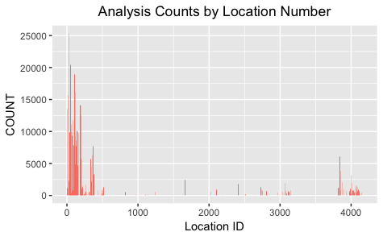

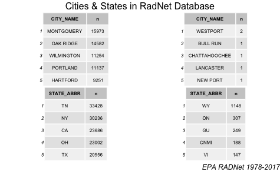

Most of the monitoring locations can be represented on a cropped map of North America. The eastern seaboard has the most monitoring stations

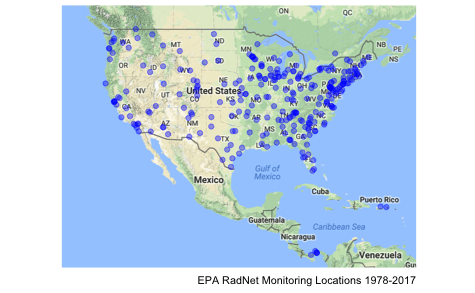

Other regions also have a few monitoring stations.

[figure not shown]

Of the half million observations about one-half are air samples (air-filter + air-charcoal).

```
    AIR-CHARCOAL       AIR-FILTER   DRINKING WATER PASTEURIZED MILK
             830           249905            41065            84249
   PRECIPITATION    SURFACE WATER
          113825            14218
```

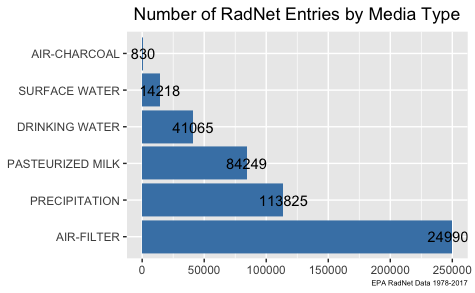

Interestingly, only $\frac{1}{2}$ of the sample ID numbers are unique. Samples IDs are replicated as many as 25 times, though most are used < 11 times. Perhaps this should not be surprising given that there are 61 different analytes, ranging from gross alpha to zirconium-95, for which each sample might be analysed. Though, *Gross Beta* accounts for nearly $\frac{1}{2}$ of the observations and the top 10 most analysed analytes account for ~85% of the dataframe observations.

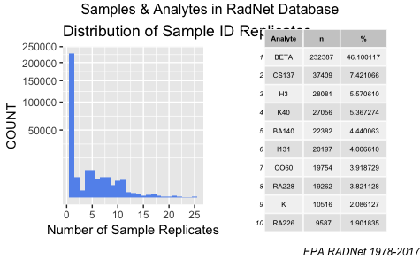

The sample sizes for each observation are interestingly grouped about the values 1, 5 and 5,000. This is not actually a valid comparison of sizes as the *unit size* is needed to provide a true comparison. The units, while indicating relative size also indicate sample type: i.e., mL and L are for liquids; mg and g for solids and ($m^3$) is for gas samples. While a small fraction of entries have no designated unit (NA) about $\frac{1}{2}$ of the measured units are for gases ($m^3$).

This information leads one down the track that about $\frac{1}{2}$ of the observations are for gross beta measurements in air samples ($m^3$).

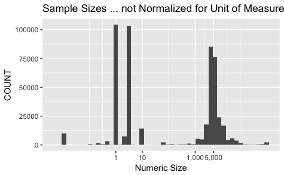

```
            G      L     M3     MG     ML
  3206     15 231564 250729    434  18144
```

There are 35 analytical procedure numbers with **Procedure 1** returned as the mode of this variable (~42% of the entries). Procedures 1 and 9 account for 74% of the entries and a small high density grouping about 120 shows procedures 118 and 119 accounting for another 19 % of the entries. Thus, most (93%) of the entries are analyzed with one of four procedures. A duration variable indicates that while most tests take under 20 hours there are some tests/procedures which are over 80 hours.

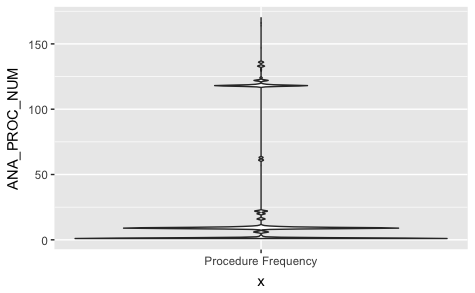

Results amounts are entered the same as sample sizes in that the direct comparison is more or less meaningless without the Result Units. Result units themselves are distributed very similar to the sample units with about $\frac{1}{2}$ of the measured units being for gases (pCi/m<sup>3</sup> and aCi/m<sup>3</sup>). Again in line with the observation that $\frac{1}{2}$ of the material IDs are for air samples.

One can plot the raw result values which show the greatest density is around 0.01 and then overlay similar plots of the minimum detectable concentration (MDC) and combined standard uncertainty (CSU). And one can see that both MDC and CSU have their greatest density at <0.001, a factor of 10 lower than the results. One interesting observation of the results data is that 16% (81,921) of the rows have no entry, result amount is NA. This seems odd as RadNet is primarily concerned with the monitoring of analytes, which requires results.

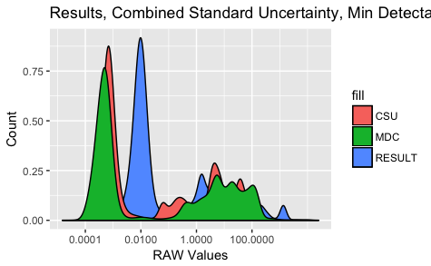

```
ACI/M3 DPM/GC    G/L  PCI/L PCI/M3
 22966     63  10585 242708 227770
```

| is.na(rad_data_raw$RESULT_AMOUNT) | n |
| --- | --- |
| FALSE | 422171 |
| TRUE | 81921 |

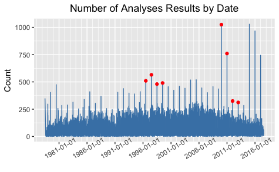

Not surprisingly for RadNet, 97.9 % of the analyses are classed as radioactive (R) versus elemental (E). Only 50% of the entries include a radioactive half-life ($t_{1/2}$), which is in line with the observation that gross beta accounts for 50% of the entries. Half-lives are only for single isotopes of an element, gross beta is not isotope specific. In this case it was easy to normalize the half-live values to one unit *years* an provide an ordered plot of radioactive half-lives. This wonderfully captures the breadth of time that is involved within this group of isotopes. The shortest-lived isotope, radon-219 has $t_{1/2}$ of 3.9 seconds compared to the longest-lived isotope, lanthanum-138 with $t_{1/2}$ = 1.05x10<sup>11</sup>, 105 billion years.

```
     E      R
 10585 493507
```

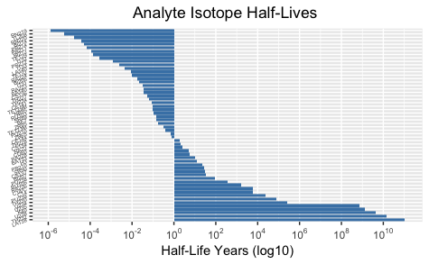

## Univariate Analysis Review

#### Dataset structure:

In review, the original dataframe had 504,092 entries with 19 variables. The variables represent different factors (some levelled), numerical values, characters and dates. Some of the variables were recast for uniformity and to help data manipulation and representation. Most notably the dates were converted to date characters in ISO 8601 format.

#### Main features of interest:

- predominant analysis types
  - materials sampled (milk, air, water: surface and precipitation)
  - analytes reviewed
- geographic information and distribution
- empty result entries (NANs)

#### Support features in the dataset:

Many of the other variables proved to be very useful in the examination of the features of interest. For example, sample IDs helped search for duplicate entries, date observations help isolate groups of data and pinpoint Radioactive release events. Location IDs in combination with City and State fields helped organize and present geographical information.

#### New variables created from existing variables:

Several new varialbles were created, especially for the handling of the geographical information. The R packages `ggmap` and `choroplethr` and the API with `geocode` all required specific formatting of the input data. Geocode also returned information (latitude and longitude). Additionally, better handling and representation of NA values led to the creation of a couple of variables specifically to identify “complete” entries. A date range variable was introduced to help filter data by ranges.

#### Data Cleansing/Unusual Distributions:

Besides the missing result data, there is any interesting long tailed positive skew for the distribution of sample replicates.

The column names were tidied and shortened. Most cleaning and date munging involved verifying and reformatting location data. A few database issues were found, e.g.: the abbreviation *PC* was not recognized by the API and was changed to “Panama Canal”; the city of Doswell, SC does not appear to exist, but several Doswell, VA observations were found in the dataframe so a single Doswell, SC was changed to VA. Several entries were listed as EPA Regions 1 to 10. In an effort to geo-locate the data, each region number was changed to the location of the headquarters for that EPA region.[^11]. Finally, a new dataframe was created with the unique city-state combinations. This remove instances where a city has multiple monitoring stations so that the google maps API would not be re-queried for the same location.

## Bivariate Analysis Plots - Variable Interactions

Using maps we can compare information by location. With a choropleth map we can plot, for instance the number of observations entered by state. This seems to correlate well to the density of monitoring stations. More entries for states that have multiple monitoring stations.

However, if we plot the number of empty entries, the trend is different. Some states with moderate/low number of observations have a higher percentage of empty results, e.g., Kentucky with <4,500 entries has > 17% empty, while California with many more samples (>19,000) has <14.8% NA results.

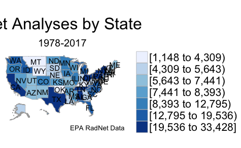

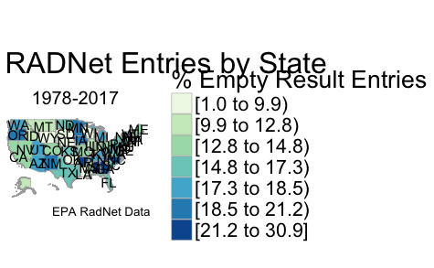

```r
#### Cross tabulation of categorical variables
empty.tab <- table(rad_data_raw$STATE_ABBR, rad_data_raw$Y)
round(prop.table(empty.tab, 1), 2)
State_noresults <- as.data.frame(round(prop.table(empty.tab, 2), 2))
State_noresults <- State_noresults[order(-State_noresults$Freq),]
chisq.test(empty.tab)

p <- ggplot(State_noresults, aes(Var1, Freq)) +
  geom_point()+
  facet_wrap(~Var2)
p
library(GGally)
ggcorr()
```

[output not shown]

Many data analyses were undertaken with a subset of the data to better understand the data and relationships between the variables. An initial subset was geographic in which data from Hawaii was filtered and reviewed. From a simple geographic map we can see that the majority of samples in Hawaii were from Honolulu and that Honolulu also has the most varied of sample types with air-Filters being the most common type of sample.

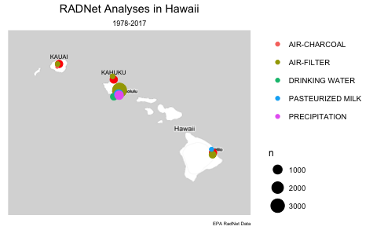

Returning to the missing (empty) result values using the Hawaii subdata shows that unlike the other sample types air-filter samples do not have a significant number of empty entries. There are also a couple of other interesting things about the Hawaiian data. First, there are no surface water analyses. Second, there is an anomalous spike of empty air-charcoal entries in 2011 for which there seems to be a corresponding spike of completed air-filter samples in the Hawaii data. As air-charcoal samples were phased out in the 1980s it seemed possible that the samples were entered in error and were re-entered as air-filter samples.

While examination of the Hawaiin air samples does confirm that of 378 air analyses entered between the end of March 2011 to April 2011 about one-half are air-charcoal (190) and the other half are air-filter analyses 188. Additionally these samples are predominantly from the same monitoring stations and less than half of the entries have unique sample IDs. However, upon a closer look, the duplication of sample IDs is due to multiple analyte tests and no sample IDs were found to be duplicated between air-filter and air-charcoal in this group. Perhaps more telling is that the air-filter sample spike is early than the air-charcoal spike. So while this is an interesting detail, more information would be needed to establish a relationship between the empty air-charcoal and air-filter samples.

[figure not shown]

Turning back to the entire database, it is noted that there are only empty entries from 1990 to 2011. Also the increase in empty entries coincides with a drop in completed entries. This is most easily seen in a frequency plot. As the number of completed entries is steady after 1990 it would seem that this is possibly a change in the sampling plan/frequency, but the empty entries contniue for more than 20 years.

The empty entries alone do not tell the entire story, as each sample may have multiple entries, one for each analyte. Looking at the analytes we find that one-quarter have numerous empty entries. Cesium-237 tops the list with 17,938 empty entries, more interesting though is Thorium-234 has 163 empty entries, but no completed entries. Are these analytes optional tests in a sampling plan or were they previously tested and phased out?

If these are optional analyte tests it is better to consider the missing results in context of the entire sample. Is the sample completley analyzed, that is all assigned analytes have results, are they incomplete having some results, or are they empty with no results?

Grouping by sample ID yields 272,004 unique sample IDs which is 54% of the database. If the entries are grouped by bothe result date and sample ID there are 26,572 more samples. While multiple analyte entries could simply be entered on different dates the data was grouped both by location and date ranges (6 mos, 1 yrs, 2 yrs) to try and determine if sample IDs were being re-issued.

When grouped by location the number of samples does not change, therefore sample IDs are not be used across multiple locations. If we track duplicate sample IDs by a 6 month date range the number of samples drops 7% which indicates at least some results are entered on different days. At a 2-year range the sample count is just barely, 0.98 % (2673) more than the original (non-date-grouped) count. As date ranges are set every 2 years from the first date it is possible that this inconsistency is an artefact of the arbitrary break, i.e., result entries may fall on both sides of any break and not actually be > 2 years different. A more thorough review would require checking differences between result dates of every duplicate. Additionally, one would need to know procedure for storing and (re)analyzing a sample to determine if a repeated sample ID is indeed the same sample. A few spot checks did turn up result dates at least 1 year apart. For the purposes of this study the data will be grouped using a 2-year date range.

Again looking through the Hawaiian data at the most popular analyte, *Beta*, a couple of sharp increases above background were noted. As the dates of these increases were studied it was found that these spikes were seen just after the nuclear accidents at the Chernobyl and Fukushima nuclear power plants in May 1986 and March 2011. When looking at the entire data set several locations registered spikes in measurement for both Fukushima and Chernobyl. In addition there are two other spikes. One incident appears localized to Tennessee in July 2008, but research did not yield any information on any nuclear incidents during this time frame. The other spike which was picked up at several monitoring stations occurred in March 1981. While the result data for the spike in NV is entered as March 3, 1981 the only nuclear accident found in this timeline was at the Tusraga Power Plant[^12], reported as being on March 8th[^13] or 9th.[^14], however, the reports were covered up for some 40 days and earlier issues at the power plant went unreported.

# Bivariate Plots Section

# Bivariate Analysis

# Multivariate Plots Section

# Multivariate Analysis

# Final Plots and Summary

# Reflection

In attempting to map the monitoring locations a few issues were found with the data. For example, the abbreviation *PC* was not recognized by the API and was changed to the full Panama Canal; the city of Doswell, SC does not appear to exist, but several Doswell, VA observations were found in the dataframe so the single entry was changed from SC to VA. Additionally several entries were listed only as EPA Regions (1-10). In an effort to geo-locate the data, the region number was updated to the location of the headquarters for that EPA region.[^15]. Also, rather than inundate the API with multiple requests for the same location a separate dataframe was created listing only unique city-state combinations. This removed the instances where a city has multiple monitoring stations (LOC_NUM).

[^1]: https://www.epa.gov/enviro/envirofacts-overview
[^2]: https://www.epa.gov/enviro/radnet-overview
[^3]: https://psychwire.wordpress.com/2011/06/03/merge-all-files-in-a-directory-using-r-into-a-single-dataframe/
[^4]: https://www.rdocumentation.org/packages/base/versions/3.4.1/topics/as.Date.
[^5]: http://cran.r-project.org/web/packages/ggmap/ggmap.pdf
[^6]: <https://blog.dominodatalab.com/geographic-visualization-with-rs-ggmaps/
[^7]: https://www.rdocumentation.org/packages/ggmap/versions/2.6.1/topics/geocode
[^8]: http://www.storybench.org/geocode-csv-addresses-r/
[^9]: https://en.wikipedia.org/wiki/Choropleth_map
[^10]: https://www.rdocumentation.org/packages/choroplethr/versions/3.6.1
[^11]: https://www.epa.gov/aboutepa#pane-4
[^12]: https://en.wikipedia.org/wiki/Tsuruga_Nuclear_Power_Plant
[^13]: http://timshorrock.com/wp-content/uploads/Chronology-of-1981-Tsuruga-Accident-from-Japanese-Press.pdf
[^14]: https://www.history.com/this-day-in-history/japanese-power-plant-leaks-radioactive-waste
[^15]: https://www.epa.gov/aboutepa#pane-4